# Coursera: Regression Models - Course Project

### Loading and Exploring the Dataset :

```r
library(knitr)
data(mtcars);kable(summary(mtcars[1:5]));kable(summary(mtcars[6:10]))
```

|  | mpg | cyl | disp | hp | drat |
| --- | --- | --- | --- | --- | --- |
|  | Min. :10.4 | Min. :4.00 | Min. : 71.1 | Min. : 52.0 | Min. :2.76 |
|  | 1st Qu.:15.4 | 1st Qu.:4.00 | 1st Qu.:120.8 | 1st Qu.: 96.5 | 1st Qu.:3.08 |
|  | Median :19.2 | Median :6.00 | Median :196.3 | Median :123.0 | Median :3.69 |
|  | Mean :20.1 | Mean :6.19 | Mean :230.7 | Mean :146.7 | Mean :3.60 |
|  | 3rd Qu.:22.8 | 3rd Qu.:8.00 | 3rd Qu.:326.0 | 3rd Qu.:180.0 | 3rd Qu.:3.92 |
|  | Max. :33.9 | Max. :8.00 | Max. :472.0 | Max. :335.0 | Max. :4.93 |

|  | wt | qsec | vs | am | gear |
| --- | --- | --- | --- | --- | --- |
|  | Min. :1.51 | Min. :14.5 | Min. :0.000 | Min. :0.000 | Min. :3.00 |
|  | 1st Qu.:2.58 | 1st Qu.:16.9 | 1st Qu.:0.000 | 1st Qu.:0.000 | 1st Qu.:3.00 |
|  | Median :3.33 | Median :17.7 | Median :0.000 | Median :0.000 | Median :4.00 |
|  | Mean :3.22 | Mean :17.8 | Mean :0.438 | Mean :0.406 | Mean :3.69 |
|  | 3rd Qu.:3.61 | 3rd Qu.:18.9 | 3rd Qu.:1.000 | 3rd Qu.:1.000 | 3rd Qu.:4.00 |
|  | Max. :5.42 | Max. :22.9 | Max. :1.000 | Max. :1.000 | Max. :5.00 |

The dataset evaluation shows that it has **10** *control variables*, **1** *target variable (mpg)* and **32** samples . Details related to the variables can easily be accessed in the **RStudio help** menu.

**Fig 1** and **Fig 2** in Appendix I, indicates that mileage, *mpg*, has a decreasing trend for an automobile for **five** of the control variables - *carb, Cyl, disp, hp & wt* and an increasing trend for other **three** - *drat, qsec, vs*, irrespective of its transmission design. For control variable *gear*, mileage shows a decreasing trend for manual transmission and an increasing trend for auto transmission. However, the gear types for auto transmission are **3, 4**, while for manual transmission, gear types are **4, 5**. This may be a reason for the difference.

**Fig 3**, Appendix I is a box plot of **mpg**(mileage) by **am**(transmission). The plot indicates that transmission design individually has a significant effect on mileage and yields the following hypothesis :

1. Manual transmission has better mileage(**mpg**) than auto transmissions.

### Data Analysis :

**mtcars** is data of **32** different automobiles, each of which has all of the 10 control variables as their features, hence the mileage would be the sum result of all these control variables. A multivariate regression model with significant, uncorrelated control variables, screened using **step** function and transmission design **(am)** as a factor variable, if significant, would be appropriate to evaluate statistical significance and practical importance of control variables on target variable.

```r
fitbase=lm(mpg~factor(am)+.-am,data=mtcars) # Multivariate regression model
fittotal=step(fitbase,trace=0) #Select best fit. trace=0 to stop step printing

#List of coefficients with 95% confidence interval, X2.5=Lower limit, X97.5=Upper limit.
kable(data.frame(summary(fittotal)$coef,confint(fittotal)))
```

|  | Estimate | Std..Error | t.value | Pr…t.. | X2.5.. | X97.5.. |
| --- | --- | --- | --- | --- | --- | --- |
| (Intercept) | 9.618 | 6.9596 | 1.382 | 0.1779 | -4.6383 | 23.874 |
| factor(am)1 | 2.936 | 1.4109 | 2.081 | 0.0467 | 0.0457 | 5.826 |
| wt | -3.917 | 0.7112 | -5.507 | 0.0000 | -5.3733 | -2.460 |
| qsec | 1.226 | 0.2887 | 4.247 | 0.0002 | 0.6346 | 1.817 |

```r
fs=summary(fittotal)$fstat;pval=pf(fs[1],fs[2],fs[3],lower.tail=F)
```

Second column, **“Estimate”** above shows the intercept, (Auto transmission, **am==0**), used as reference has high practical importance and coefficients (slope) of each control variable, which are essentially the rate at which the *target variable*, **mpg** increases for each unit change in the relevant *control variable*, keeping all other variables constant. Coefficient for manual transmission, **factor(am)1**, has a positive value relative to intercept indicating that *manual transmission has a better mpg relative to auto transmission* for all other variables held constant. Also the P value, **0.0467**, (column Pr) for a confidence interval of 95%($\alpha$=**0.05**) indicates that it is **statistically significant**. Coefficients also show that only **two other** control variables - *wt & qsec* - have a statitically significant effect on *mpg*.

Fifth, sixth and seventh columns - **Pr, X2.5 & X97.5** show that all control variables, except the intercept (Autotransmission), have a P-value (**Pr**) less than the significance level, $\alpha$=0.05, the 95% confidence significance level, with confidence intervals (**X2.5 & X97.5**) not containing 0, hence, null-hypothesis for each of the control variables is *rejected*, i.e these control variables have statistically significant effect. Also, the P-value for the regression as a whole is **1.2104 × 10<sup>-11</sup>**, is less than the significance level, $\alpha$=0.05, **rejecting** the null-hypothesis. Hence we can infer that the important control variables have a significant effect on *mpg* for 95% confidence interval. Also that *Manual transmission has 30.53% better mpg relative to Auto transmission*. Mulitple R-Squared shows that the analysis explains 84.97% of variance.

***For the complete model summary refer to Appendix I*

#### Shapiro-Wikes Test:

```r
s.test=shapiro.test(fittotal$resid);print(s.test)
```

```
||
||  Shapiro-Wilk normality test
||
|| data:  fittotal$resid
|| W = 0.9411, p-value = 0.08043
```

### Conclusion:

Above set of analysis yields the inference that **Manual transmission is better than Auto transmission** with **30.53%** better mileage(mpg), while accounting for significant confounders.

# Appendix I :

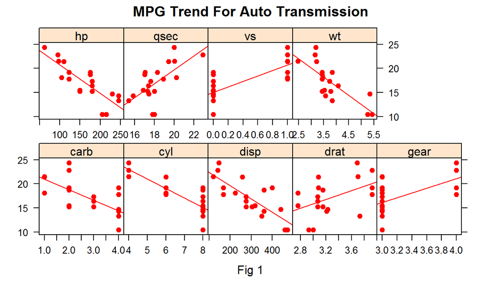

```r
library(caret)
par(mfrow=c(2,1))
featurePlot(mtcars[mtcars$am==0,-c(1,9)],mtcars$mpg[mtcars$am==0],type=c('p','r'),
col='red',labels=c("Fig 1",""),main="MPG Trend For Auto Transmission",pch=19)
```

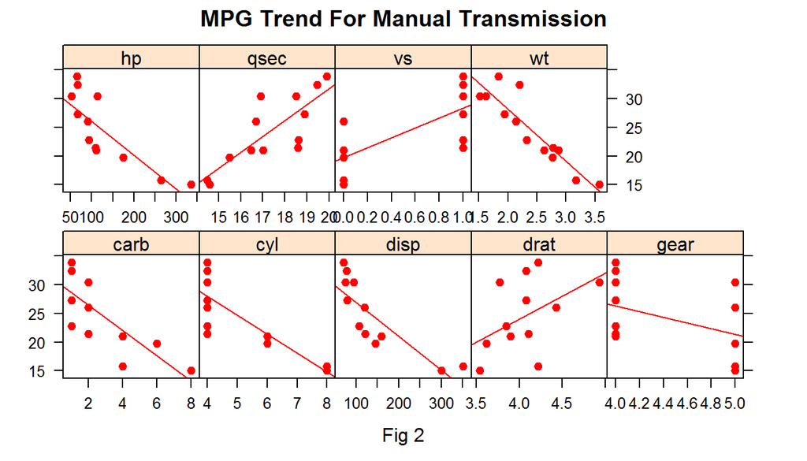

```r
featurePlot(mtcars[mtcars$am==1,-c(1,9)],mtcars$mpg[mtcars$am==1],type=c('p','r'),
col='red',labels=c("Fig 2",""),main="MPG Trend For Manual Transmission",pch=19)
```

#### Detailed Summary Of Multivariate Regression :

```r
summary(fittotal)
```

```
Call:
lm(formula = mpg ~ factor(am) + wt + qsec, data = mtcars)

Residuals:
   Min     1Q Median     3Q    Max
-3.481 -1.556 -0.726  1.411  4.661

Coefficients:
            Estimate Std. Error t value Pr(>|t|)
(Intercept)    9.618      6.960    1.38  0.17792
factor(am)1    2.936      1.411    2.08  0.04672 *
wt            -3.917      0.711   -5.51    7e-06 ***
qsec           1.226      0.289    4.25  0.00022 ***
---
Signif. codes:  0 '***' 0.001 '**' 0.01 '*' 0.05 '.' 0.1 ' ' 1

Residual standard error: 2.46 on 28 degrees of freedom
Multiple R-squared:  0.85,  Adjusted R-squared:  0.834
F-statistic: 52.7 on 3 and 28 DF,  p-value: 1.21e-11
```

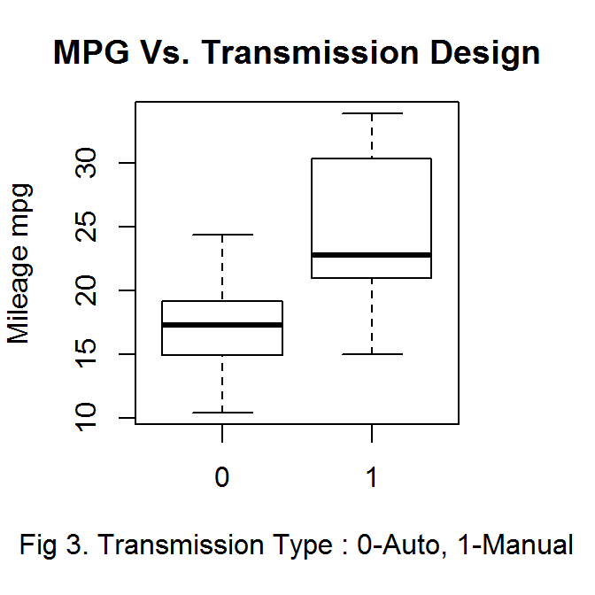

```r
par(mar=c(5,4,3,4))
boxplot(mpg~am,data=mtcars,xlab="Fig 3. Transmission Type : 0-Auto, 1-Manual",ylab="Mileage mpg",
        main="MPG Vs. Transmission Design")
```

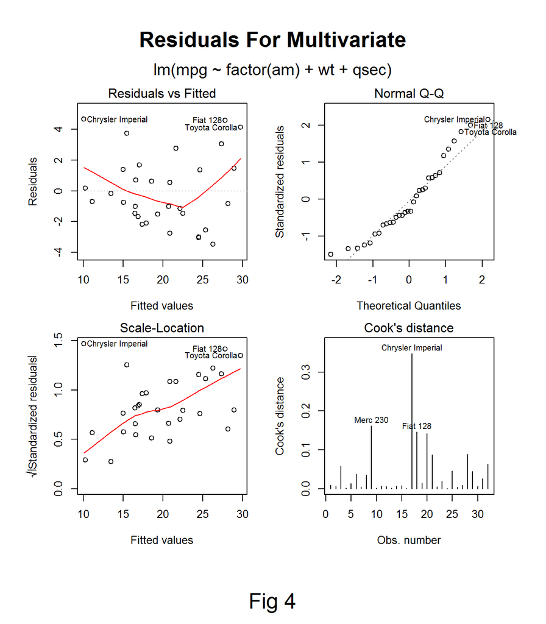

```r
par(mfrow=c(2,2),oma=c(6,2,6,2),mar=c(4,4,2,2))
plot(fittotal,1:4);title(main="Residuals For Multivariate",sub="Fig 4",outer=T,cex.main=2,cex.sub=2)
```